# TRABALHO 1 - Natalidade/Fecundidade e Mortalidade

Demografia 1.2022 - Professora Ana Maria Nogales

Gabriel Peixoto Veiga[^1]

João Victor Maia[^2]

Marco Aurélio[^3]

Rafael de Acypreste[^4]

19/08/2022

[figure not shown]

## Introdução

Neste documento, estão os explicados os procedimentos para as respostas ao Primeiro trabalho: `TRABALHO 1 - Natalidade/Fecundidade e Mortalidade`, cujo prazo de entrega é dia 22/08/2022. Os pacotes utilizados foram:

```r
if (!require("pacman")) install.packages("pacman")

if (!require("microdatasus")) {
  pacman::p_load("remotes")
  remotes::install_github("rfsaldanha/microdatasus")
}

pacman::p_load("microdatasus", ## Download dos dados de 2000 a 2020
               "tidyverse",    ## Pacote de utilidades para manipulação e visualização
               "kableExtra",   ## Elaboração das tabelas em LaTeX e html
               "lubridate",
               "readxl",
               "LexisPlotR",   ## Pacote para Diagramas de Lexix
               "data.table",
               "scales")


options(scipen = 99)
```

Agora, pode-se baixar os dados básicos para elaboração do trabalho.

### Dados de Nascidos Vivos a partir do SINASC

#### Microdados DATASUS

Os microdados do SINASC de 2000 a 2020 foram baixados com a ajuda do pacote [`microdatasus`](https://github.com/rfsaldanha/microdatasus), criado por Raphael de Freitas SALDANHA, Ronaldo Rocha BASTOS e Christovam BARCELLOS[^5]. Os procedimentos de pré-processamento dos micradodos realizados podem ser encontrados na plataforma [GitHub](https://github.com/rfsaldanha/microdatasus/wiki/Conven%C3%A7%C3%B5es-SINASC). Os dados para o Estado de Pernambuco podem ser baixados por

```r
  # Download dos microdados do datasus
dados_sinasc <- fetch_datasus(
  year_start         = 2000,
  year_end           = 2020,
  uf                 = "PE",
  information_system = "SINASC"
)
```

### Dados preliminares 2021

Para o ano de 2021, há apenas dados preliminares que podem ser acessados e filtrados em:

```r
  # Repositório Ministério da Saúde
file <- "https://svs.aids.gov.br/dantps/centrais-de-conteudos/dados-abertos/sinasc/DN21OPEN.zip"

  # Cria arquivo temporário para download do arquivo .zip
temp <- tempfile()

  # Download do arquivo
utils::download.file(file, temp, mode = "wb")


  # Cria pasta temporária para descompactar arquivo .zip
tempd <- tempdir()

  # Descompacta o arquivo
unzip(temp, exdir = tempd)


dados_sinasc_2021 <- foreign::read.dbf(file.path(tempd, "DN21OPEN.dbf")) %>% # Importa a tabela .dbf
  filter(str_detect(CODMUNRES, "^26")) # Filtra pessoas residentes apenas em PE

  # Remove arquivo e pasta temporárias
file.remove(temp)
unlink(tempd)
```

Os microdados do SIM de 2000 a 2020 foram baixados com a ajuda do pacote [`microdatasus`](https://github.com/rfsaldanha/microdatasus). As convenções adotadas no SIM podem ser encontradas no [GitHub](https://github.com/rfsaldanha/microdatasus/wiki/Conven%C3%A7%C3%B5es-SIM). Os dados para o Estado de Pernambuco podem ser baixados por

```r
dados_sim <- fetch_datasus(
  year_start         = 2000,
  year_end           = 2020,
  uf                 = "PE",
  information_system = "SIM-DO"
)
```

### Dados preliminares de óbitos (2021)

De maneira semelhante aos dados de nascimentos, há apenas dados preliminares, que podem ser acessados e baixados por:

```r
  # Mesmo procedimento para os dados do SINASC
file <- "https://svs.aids.gov.br/dantps/centrais-de-conteudos/dados-abertos/sim/DO21OPEN.zip"
temp <- tempfile()
tempd <- tempdir()

utils::download.file(file, temp, mode = "wb")


unzip(temp, exdir = tempd)


dados_sim_2021 <-
  foreign::read.dbf(file.path(tempd, "DO21OPEN.dbf")) %>% # Importa a tabela .dbf
  filter(str_detect(CODMUNRES, "^26")) # Filtra pessoas residentes apenas em PE


file.remove(temp)
unlink(tempd)
```

Também são necessários dados de projeção populacional para o Estado de Pernambuco. Nesse caso, foram utilizadas as projeções elaboradas pelo próprio IBGE e disponíveis [aqui](https://www.ibge.gov.br/estatisticas/sociais/populacao/9109-projecao-da-populacao.html?=&t=resultados).

Com isso, tem-se as projeções populacionais por sexo e idade. Os dados de projeção populacional do IBGE podem ser acessados em:

```r
  # Repositório do IBGE para a tabela .xls
file <-
  "https://ftp.ibge.gov.br/Projecao_da_Populacao/Projecao_da_Populacao_2018/projecoes_2018_populacao_idade_simples_2010_2060_20201209.xls"

  # Arquivo temporário para download da tabela
temp_pop <- tempfile()

  # Download da tabela em formato compatível com Windows
download.file(url      = file,
              destfile =  temp_pop,
              mode     = "wb")
```

Agora, para acessar as questões, basta navegar no menu suspenso acima.

## Questão 1: Diagrama de Lexis

**a)** *Construir o Diagrama de Lexis para os dados de nascidos vivos de 2000 a 2021 da UF escolhida (SINASC) e de óbitos menores de 5 anos (idades simples) para o mesmo período segundo ano de nascimento.*

O Diagrama de Lexis solicitado é:

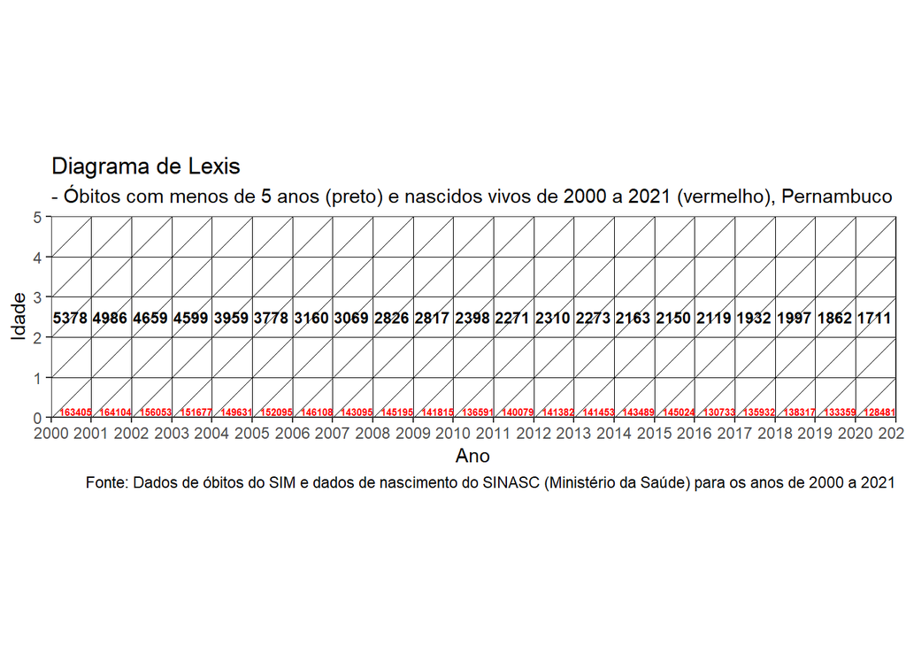

Figure 1: Elaboração própria.

**b)** *Supondo população fechada (inexistência de migração), calcule a probabilidade de um recém-nascido na UF ou território de escolha sobreviver à idade exata 5 para as coortes de 2000 a 2016.*

As probabilidades de um recém-nascido sobreviver aos 5 anos em Pernambuco entre os anos de 2000 e 2016 estão na tabela 1 abaixo.

Table 1: Probabilidade de um recém-nascido em Pernambuco sobreviver à idade exata 5 anos

| Ano de Nascimento | Probabilidade de sobrevivência |
| --- | --- |
| 2000 | 0.96709 |
| 2001 | 0.96962 |
| 2002 | 0.97014 |
| 2003 | 0.96968 |
| 2004 | 0.97354 |
| 2005 | 0.97516 |
| 2006 | 0.97837 |
| 2007 | 0.97855 |
| 2008 | 0.98054 |
| 2009 | 0.98014 |
| 2010 | 0.98244 |
| 2011 | 0.98379 |
| 2012 | 0.98366 |
| 2013 | 0.98393 |
| 2014 | 0.98493 |
| 2015 | 0.98517 |
| 2016 | 0.98379 |

Fonte: Dados do SIM do Ministério da Saúde referentes aos óbitos e dados do SINASC referentes aos nascimentos.

**c)** *Considerando o mesmo pressuposto, calcule a probabilidade de sobreviver ao primeiro aniversário dos recém-nascidos no período de 2000 a 2020.*

As probabilidades de um recém-nascido sobreviver ao primeiro aniversário em Pernambuco entre os anos de 2000 a 2020 estão na tabela 2 abaixo.

Table 2: Probabilidade de um recém-nascido em Pernambuco sobreviver ao primeiro aniversário

| Ano de Nascimento | Probabilidade de sobrevivência |
| --- | --- |
| 2000 | 0.97102 |
| 2001 | 0.97375 |
| 2002 | 0.97427 |
| 2003 | 0.97387 |
| 2004 | 0.97723 |
| 2005 | 0.97849 |
| 2006 | 0.98140 |
| 2007 | 0.98147 |
| 2008 | 0.98323 |
| 2009 | 0.98303 |
| 2010 | 0.98497 |
| 2011 | 0.98619 |
| 2012 | 0.98592 |
| 2013 | 0.98599 |
| 2014 | 0.98692 |
| 2015 | 0.98715 |
| 2016 | 0.98610 |
| 2017 | 0.98792 |
| 2018 | 0.98768 |
| 2019 | 0.98790 |
| 2020 | 0.98849 |

Dados do SIM do Ministério da Saúde referentes aos óbitos e dados do SINASC referentes aos nascimentos.

**d)** *Comente sobre os valores encontrados. Não esquecer a qualidade da informação trabalhada.*

## Questão 2: Natalidade/Fecundidade

**a)** *Com base nos dados do SINASC para os de 2019 a 2021 e na população por sexo e idade estimada (projetada - 2020), construa os seguintes indicadores para a Unidade da Federação:*

1. Taxa Bruta de Natalidade;
2. Taxa Fecundidade Geral (TFG) e Taxas específicas de fecundidade;
3. Taxa de Fecundidade Total (TFT) ou Índice Sintético de Fecundidade;
4. Taxas específicas de fecundidade feminina (apenas os nascimentos femininos);
5. Taxa Bruta de Reprodução;
6. Taxa Líquida de Reprodução (é necessária a informação da função L da Tábua de Vida).

A **Taxa Bruta de Natalidade (ou Coeficiente Geral de Natalidade)**, de acordo com a Rede Interagencial de Informações sobre a Saúde [RIPSA](http://tabnet.datasus.gov.br/cgi/idb2000/fqa06.htm), expressa a frequência anual de nascidos vivos e é dada pelo número total de nascidos vivos sobre a população total de residentes de uma determinada região. Para o estado de Pernambuco tal taxa foi de 13.442553 por mil habitantes.

Já a **Taxa de Fecundidade Geral (TFG)** refere-se à divisão, em um determinado ano, do total de nascidos vivos pela população feminina em período fértil (15 a 49 anos de idade). Em Pernambuco, essa taxa foi de 0.0482599.

As **Taxas específicas de fecundidade feminina (TEFs)** correspondem à divisão do total de nascimentos vivos de uma determinada idade ou grupo etário pelo total de mulheres dessa idade ou grupo etário em um determinado ano. Os dados foram:

- Para a faixa etária entre 15 a 19 anos:

0.3293996

- Entre 20 e 24 anos:

0.3094362

- Entre 25 e 29 anos:

0.319833

- Entre 30 e 34 anos:

0.3123977

- Entre 35 e 39 anos:

0.3194267

- Entre 40 e 44 anos:

0.341941

- Entre 45 e 49 anos:

0.3830264

A **Taxa Bruta de Reprodução** assemelha-se à Taxa Bruta de Natalidade, diferenciando-se desta última apenas por considerar somente o número de **filhas** nascidas vivas. O valor desta taxa, calculada para o estado de Pernambuco por mil habitantes é 23.6103044.

A **Taxa Líquida de Reprodução** relaciona-se ao número de filhas tidas, por mulher, durante sua idade reprodutiva. Para o estado de Pernambuco, este valor é 0.0229611.

**b)** *Compare os seus resultados com os valores obtidos pelo estudo GBD, pela Nações Unidas (UN Population) e aqueles publicados no site do Datasus (RIPSA - Indicadores e dados básicos). Como os indicadores de reprodução não aparecem nessas listas, a partir das TFT, calcule esses indicadores para comparação.*

**c)** *Para os dados do SINASC para 2021, analise a associação entre (apresente ao menos uma medida de associação)*:

1. Idade e Escolaridade da Mãe:

Em um primeiro momento, é importante conceituar a ideia de **gravidez na adolescência**, que diz respeito à proporção de nascidos vivos por mães na faixa etária entre 10 a 19 anos. Importante ressaltar que na faixa etária entre 10 e 14 anos há, não raramente, presunção de violência.

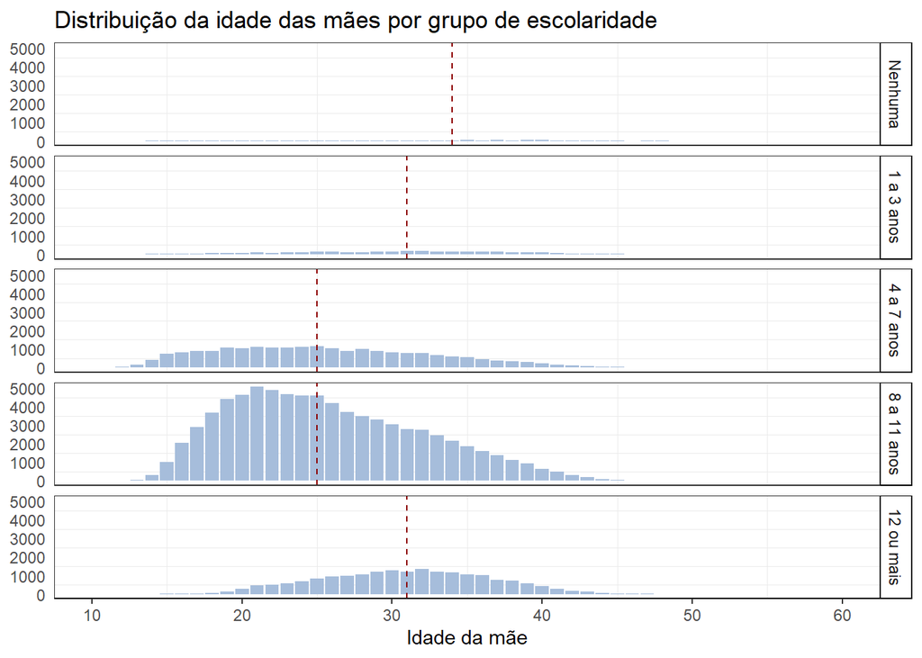

Figure 2: Elaboração própria.

**d)** *Comente esses resultados (inclusive os gráficos das nfx), fazendo referência a artigos já publicados sobre o assunto.*

Para esta questão, foi escolhida a relação entre idade e escolaridade da mãe, referente aos dados do SINASC para 2021 no Estado de Pernambuco. Para tanto, faz-se necessário a análise de dados que possam dar luz às relações entre a interação das duas variáveis citadas na mortalidade neonatal, considerando a baixa escolaridade, bem como a incidência de gravidez nos estratos mais baixos da [pirâmide etária brasileira](https://educa.ibge.gov.br/jovens/conheca-o-brasil/populacao/18318-piramide-etaria.html) enquanto fatores de risco.

De acordo com artigo publicado no Volume 51 da Revista de Saúde Pública da Universidade de São Paulo, pelos pesquisadores **Sandra Costa Fonseca; Patricia Viana Guimarães Flores; Kenneth Rochel Camargo; Rejane Sobrino Pinheiro e Claudia Medina Coeli**, intitulado [Escolaridade e idade materna: desigualdades no óbito neonatal](https://rsp.fsp.usp.br/artigo/escolaridade-e-idade-materna-desigualdades-no-obito-neonatal/), “em todos os estratos de idade, filhos de mães com escolaridade inferior a quatro anos apresentam maior chance de óbito neonatal, quando comparados aos filhos de mães com pelo menos quatro anos de escolaridade” (FONSECA SC et al., 2017, p. 03).

O mesmo estudo cita o artigo, publicado na revista Lancet e intitulado [Socioeconomic inequality in neonatal mortality in countries of low and middle income; a multicountry analysis](https://linkinghub.elsevier.com/retrieve/pii/S2214109X14700087) de Mckinnon et al, que aponta uma redução da Taxa de Mortalidade Neonatal em associação com com mudança nos indicadores de desigualdade educacional – moderada para redução absoluta e fraca para redução relativa.

## Questão 3: Mortalidade

**a)** *Com base nos dados sobre óbitos do SIM para 2019 a 2021 e a população por sexo e idade estimada (projetada) em 2020 para a UF, obtenha os seguintes indicadores:*

Em primeiro lugar, deve-se acessar os dados conforme a seção introdutória.

> - Taxa Bruta de Mortalidade

Taxa Bruta de Mortalidade diz respeito ao total do número de óbitos, por mil habitantes, na população residente no local e período de interesse. No presente exercício, avaliamos a taxa no Estado de Pernambuco, com o período centrado no ano de 2020.

O número de óbitos em 2020 contabilizado a partir da média móvel entre 2019 e 2021.

Portanto, a Taxa Bruta de Mortalidade para o Estado de Pernambuco em 2020 foi 7.6737 por mil habitantes.

> - Taxas específicas de mortalidade por sexo e idade - nMx (grafique)

As projeções populacionais por sexo e idade já foram coletadas na questão 2 e serão aproveitadas nesta.

Em seguida, pode-se contabilizar o número de óbitos por faixa etária no ano de 2020, bem como contabilizar as taxas específicas de mortalidade por sexo e idade (nMx):

| Faixa Etária | Óbitos Masculinos | Óbitos Femininos | População Masculina | População Feminina | nMx Masculina | nMx Feminina |
| --- | --- | --- | --- | --- | --- | --- |
| < 1 | 826 | 634 | 70154 | 66941 | 0.01177 | 0.00947 |
| 1-4 | 127 | 105 | 280242 | 267447 | 0.00045 | 0.00039 |
| 5-9 | 86 | 54 | 361571 | 345444 | 0.00024 | 0.00016 |
| 10-14 | 99 | 104 | 373149 | 358097 | 0.00027 | 0.00029 |
| 15-19 | 781 | 191 | 393865 | 382499 | 0.00198 | 0.00050 |
| 20-24 | 1305 | 240 | 410796 | 407176 | 0.00318 | 0.00059 |
| 25-29 | 1195 | 300 | 379917 | 393940 | 0.00315 | 0.00076 |
| 30-34 | 1249 | 391 | 374759 | 403316 | 0.00333 | 0.00097 |
| 35-39 | 1401 | 555 | 359621 | 394441 | 0.00390 | 0.00141 |
| 40-44 | 1633 | 885 | 330663 | 368470 | 0.00494 | 0.00240 |
| 45-49 | 1897 | 1094 | 287981 | 328946 | 0.00659 | 0.00333 |
| 50-54 | 2485 | 1580 | 254677 | 298539 | 0.00976 | 0.00529 |
| 55-59 | 2962 | 2021 | 214333 | 257387 | 0.01382 | 0.00785 |
| 60-64 | 3511 | 2522 | 168901 | 210936 | 0.02079 | 0.01196 |
| 65-69 | 4006 | 3093 | 127512 | 170522 | 0.03142 | 0.01814 |
| 70-74 | 4413 | 3723 | 97692 | 134528 | 0.04517 | 0.02767 |
| 75-79 | 4284 | 4177 | 62887 | 94017 | 0.06812 | 0.04443 |
| 80-84 | 3993 | 4618 | 39304 | 64617 | 0.10159 | 0.07147 |
| 85-89 | 2745 | 3710 | 18011 | 32782 | 0.15241 | 0.11317 |
| 90+ | 2706 | 4442 | 10229 | 20763 | 0.26454 | 0.21394 |

Note: Dados do SIM do Ministério da Saúde referentes à média móvel de 3 anos centralizada 2020. Dados de projeções populacionais disponibilizados pelo IBGE.

O gráfico das taxas pode ser visualizado abaixo. Atente-se para o eixo vertical, que está em escala logarítmica de base 10.

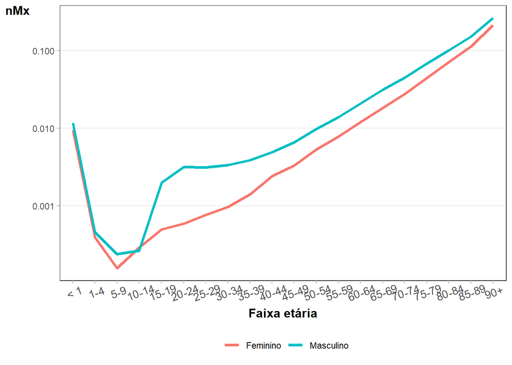

Figure 3: Elaboração própria.

**b)** *Calcule a TMI, utilizando o número médio de óbitos ocorridos entre 2019 e 2021 e o número de nascimentos de 2020. Calcule os indicadores: taxa de mortalidade neonatal, neonatal precoce, neonatal tardia, posneonatal. Agregando a informação sobre óbitos fetais para os mesmos anos, calcule a taxa de mortalidade perinatal.*

A Taxa de Mortalidade Infantil com média móvel de mortes centrada em 2020 pelo número de nascimentos em 2020 por mil habitantes foi de 11.9291.

Os dados para o Estado de Pernambuco são:

Table 3: Taxas de mortalidade infantil por mil nascidos vivos

| Infantil | Neonatal | Neonatal precoce | Neonatal tardia | Posneonatal | Perinatal |
| --- | --- | --- | --- | --- | --- |
| 11.929 | 8.538 | 6.561 | 1.977 | 3.391 | 17.232 |

Dados de mortalidade infantil em média móvel entre 2019 e 2021 do SIM do Ministério da Saúde. Os dados populacionais são referentes às projeçoes do IGBE para o ano de 2020. Para a contabilidade da Taxa Perinatal, foram somados os dados de óbitos fetais aos dados de nascidos vivos.

**c)** *Compare os seus resultados com os valores obtidos pelo estudo GBD, pela Nações Unidas (UN Population) e aqueles publicados no site do Datasus ([RIPSA - Indicadores e dados básicos](http://tabnet.datasus.gov.br/cgi/idb2012/matriz.htm)). Para a TMI, compare com os valores obtidos na questão 1. Comente sobre os aspectos metodológicos dessas duas formas de cálculo.*

Os dados do [Global Burden of Disease 2019](https://ghdx.healthdata.org/gbd-2019) coleciona informações de pesquisas, censos e estatísticas vitais e sanitárias, permitindo a comparação entre países. As informações estão disponíveis no [Global Burden of Disease Study 2019 (GBD 2019) Data Resources](https://ghdx.healthdata.org/gbd-2019).

Trata-se de dados referentes à probabilidade de morte, que é definida pelo GBD[^6] como a probabilidade de uma pessoa morrer entre dois intervalos de tempo se as taxas de mortalidade por qualquer causa num ano específico de interesse — em nosso caso, o último ano, que é 2019 — se mantiverem constante no futuro.

Um resumo para o caso de Pernambuco pode ser visto em

Table 4: Taxas de probabilidade de morte (por mil)

| Early Neonatal | Late Neonatal | Neonatal |
| --- | --- | --- |
| 9.481 | 2.109 | 11.57 |

Taxas de probabilidade de morte nas catetorias Neonatal, Neonatal Precoce (Early Neonatal) e Neonatal tardia (Late Neonatal). Fonte: Global Burden of Disease 2019.

Já os dados da Rede Interagencial de Informações para a Saúde (RIPSA)[^7]. Os dados apresentados abaixo podem ter sido calculados de duas maneiras distintas[^8]

1. *Direto*: em que são contabilizados os óbitos no período etário considerado por mil nascidos vivos na população residente no espaço geográfico considerado.
2. *Indireto*: estimativa por técnicas demográficas especiais, aplicado quando os estados que apresentam cobertura do Sinasc inferior a 90% ou que não atingem o valor de 80% de um índice composto, especialmente criado, que combina a cobertura de óbitos infantis com a regularidade do SIM".

Esses detalhes metodológicos dos indicadores estão explicados no documento [Indicadores Básicos para a Saúde no Brasil: Conceitos e aplicações](http://tabnet.datasus.gov.br/tabdata/livroidb/2ed/indicadores.pdf).

Table 5: Taxas de Mortalidade Infantil por mil (2011)

| Taxa de mortalidade infantil | Taxa de mortalidade infantil neonatal precoce | Taxa de mortalidade infantil neonatal tardia | Taxa de mortalidade infantil neonatal | Taxa de mortalidade infantil pós-neonatal |
| --- | --- | --- | --- | --- |
| 15.64 | 8.23 | 2.33 | 10.56 | 5.08 |

Taxas de mortalidade infantil (2011). Fonte: Rede Interagencial de Informações para a Saúde.

Com isso, pode-se avaliar os valores conjuntamentes como abaixo:

Table 6: Comparação das Taxas de Mortalidade Infantil por mil

| Fonte | Ano | Infantil | Neonatal | Neonatal precoce | Neonatal tardia | Posneonatal | Perinatal |
| --- | --- | --- | --- | --- | --- | --- | --- |
| SIM-SINASC (Microdados) | 2020 | 11.929 | 8.538 | 6.561 | 1.977 | 3.391 | 17.232 |
| RIPSA | 2011 | 15.640 | 10.560 | 8.230 | 2.330 | 5.080 | NA |
| GBD | 2019 | NA | 11.570 | 9.481 | 2.109 | NA | NA |

Fonte: Rede Interagencial de Informações para a Saúde.

Pode-se perceber que os valores levantados no presente trabalho são menores do que os levantados nos boletins da RIPSA e do GBD. Em parte, esse fenômeno se deve a uma tendência constante de reduções das taxas de mortalidade infantil nos últimos períodos no país e também em Pernambuco, como se pode perceber [aqui](https://cidades.ibge.gov.br/brasil/pe/pesquisa/39/30279?ano=2017).

Entretanto, parte dessa discrepância pode ser resultado de uma subnotificação dos dados de nascimento e de mortalidade infantil nos próprios SINASC e SIM. Como não foi feito ajuste no presente trabalho, há uma tendência de subestimação das referidas taxas. Já o GBD utiliza fontes de dados e metodologia própria de estimação das taxas, oferecendo até mesmo um intervalo de confiança para as estimações. Por outro lado, os dados do RIPSA, além de serem um pouco mais antigos, podem ter utilizado a metodologia indireta como explicitada acima.

**d)** *Compare a estrutura de mortalidade por causas (Capítulos da CID10 - reagrupados em 6/7 grandes causas) segundo sexo de 2015 e 2021. Comente os resultados. Destacar a mortalidade por Covid-19 (CID B34.2).*

Table 7: Comparação das Estruturas de Mortalidade por Grupos de Causas, segundo o sexo, entre os anos de 2015 e 2021

| Causas | 2015 Homens | 2015 Mulheres | 2021 Homens | 2021 Mulheres |
| --- | --- | --- | --- | --- |
| Algumas afecções originadas no período perinatal | 0.138 | 0.098 | 0.250 | 0.202 |
| Causas externas | 1.537 | 0.270 | 1.456 | 0.309 |
| Demais causas definidas | 1.514 | 1.321 | 1.859 | 1.643 |
| Doenças do aparelho circulatório | 2.026 | 1.791 | 1.830 | 1.688 |
| Doenças do aparelho respiratório | 0.862 | 0.860 | 0.812 | 0.771 |
| Doenças infecciosas e parasitárias | 0.369 | 0.267 | 0.377 | 0.285 |
| Neoplasias | 0.955 | 0.909 | 0.969 | 0.975 |

Fonte: Dados do SIM do Ministério da Saúde referentes aos óbitos.

**e)** *Construa Tábuas de Vida para cada sexo para a UF escolhida para 2020, a partir das taxas específicas de mortalidade obtidas no item a:*

- *Utilize a TMI obtida no item b ou do estudo Global Burden of Disease - GBD. Lembre que deve-se obter a TMI para cada sexo em separado.*
- *Estime os fatores de separação, para cada sexo, para as idades 0-1 e 1-4 com base nos dados do SIM.*
- *Compare os valores da função esperança de vida para as idades exatas 0 e 60 com aqueles obtidos pelo estudo GBD, pela Nações Unidas (UN Population) e aqueles publicados no site do Datasus (RIPSA - Indicadores e dados básicos - http://tabnet.datasus.gov.br/cgi/idb2012/matriz.htm ). . Comente sobre os resultados obtidos e sobre o significado desses indicadores.*
- *Com base na TV calculada, grafique as funções lx e nqx para cada sexo e comente os resultados. Se lo=1, qual o significado da função lx? Interprete, neste caso, l20 e l60.*
- *Comente os resultados à luz de artigos recém publicados.*

Table 8: Tábua de Vida - Homens

x

n

nMx

nkx

nqx

lx

ndx

nLx

Tx

ex

0

1

0.012

0.110

0.012

100000.00

1240.000

98896.4

6407971.9

64.080

1

4

0.000

1.800

0.003

98760.00

294.306

394392.5

6309075.5

63.883

5

5

0.000

2.500

0.002

98465.69

159.502

491929.7

5914683.0

60.068

10

5

0.000

2.500

0.002

98306.19

244.744

490919.1

5422753.3

55.162

15

5

0.002

2.500

0.016

98061.45

1559.082

486409.5

4931834.2

50.293

20

5

0.003

2.500

0.024

96502.37

2270.196

476836.3

4445424.7

46.065

25

5

0.003

2.500

0.023

94232.17

2161.397

465757.4

3968588.3

42.115

30

5

0.003

2.500

0.024

92070.77

2194.251

454868.2

3502831.0

38.045

35

5

0.004

2.500

0.027

89876.52

2437.652

443288.5

3047962.7

33.913

40

5

0.005

2.500

0.034

87438.87

2976.688

429752.6

2604674.2

29.789

45

5

0.006

2.500

0.045

84462.18

3832.218

412730.4

2174921.6

25.750

50

5

0.009

2.500

0.067

80629.96

5373.392

389716.3

1762191.2

21.855

55

5

0.012

2.500

0.093

75256.57

7019.690

358733.6

1372474.9

18.237

60

5

0.018

2.500

0.138

68236.88

9417.742

317640.1

1013741.3

14.856

65

5

0.027

2.500

0.205

58819.14

12070.783

263918.7

696101.2

11.835

70

5

0.039

2.500

0.291

46748.36

13585.905

199777.0

432182.5

9.245

75

5

0.060

2.500

0.453

33162.45

15022.226

128256.7

232405.5

7.008

80

0.125

5.741

1.000

18140.23

18140.226

104148.8

104148.8

5.741

Fonte: Dados do SIM do Ministério da Saúde referentes aos óbitos.

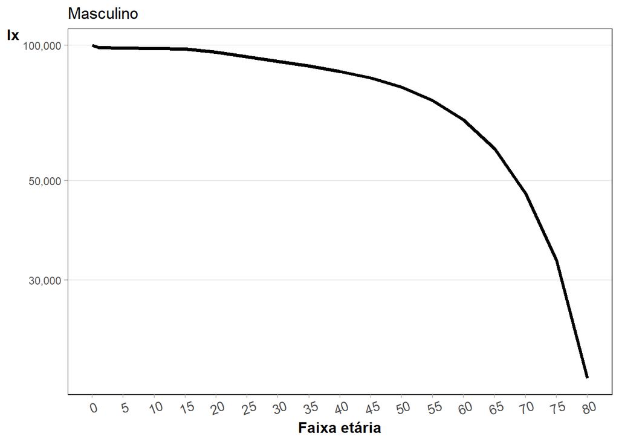

Figure 4: Elaboração própria.

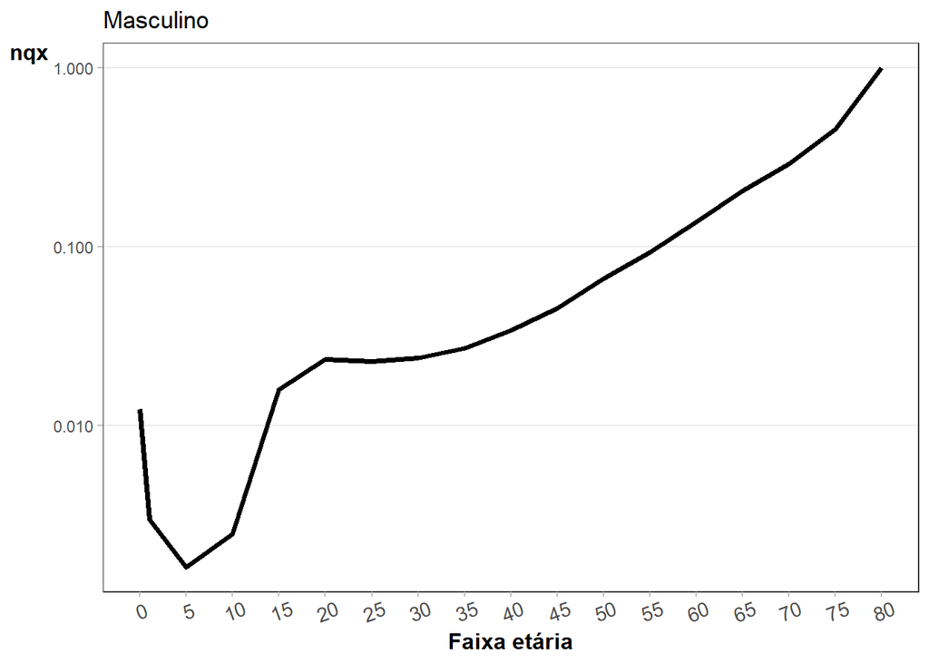

Figure 5: Elaboração própria.

Table 9: Tábua de Vida - Mulheres

x

n

nMx

nkx

nqx

lx

ndx

nLx

Tx

ex

0

1

0.010

0.110

0.010

100000.00

1020.000

99092.2

7317813.3

73.178

1

4

0.000

1.800

0.003

98980.00

277.195

395310.2

7218721.1

72.931

5

5

0.000

2.500

0.001

98702.80

135.816

493174.5

6823411.0

69.131

10

5

0.000

2.500

0.002

98566.99

174.083

492399.7

6330236.5

64.223

15

5

0.000

2.500

0.003

98392.91

332.875

491132.3

5837836.7

59.332

20

5

0.001

2.500

0.004

98060.03

394.358

489314.3

5346704.4

54.525

25

5

0.001

2.500

0.005

97665.67

477.799

487133.9

4857390.1

49.735

30

5

0.001

2.500

0.007

97187.87

659.307

484291.1

4370256.3

44.967

35

5

0.001

2.500

0.009

96528.57

915.645

480353.7

3885965.2

40.257

40

5

0.002

2.500

0.016

95612.92

1482.248

474359.0

3405611.5

35.619

45

5

0.003

2.500

0.022

94130.67

2057.988

465508.4

2931252.5

31.140

50

5

0.005

2.500

0.035

92072.69

3247.599

452244.4

2465744.1

26.780

55

5

0.007

2.500

0.052

88825.09

4621.514

432571.7

2013499.6

22.668

60

5

0.010

2.500

0.078

84203.57

6541.482

404664.2

1580928.0

18.775

65

5

0.016

2.500

0.122

77662.09

9437.273

364717.3

1176263.8

15.146

70

5

0.025

2.500

0.186

68224.82

12674.133

309438.8

811546.5

11.895

75

5

0.040

2.500

0.301

55550.68

16706.744

235986.6

502107.8

9.039

80

0.101

6.851

1.000

38843.94

38843.941

266121.2

266121.2

6.851

Fonte: Dados do SIM do Ministério da Saúde referentes aos óbitos.

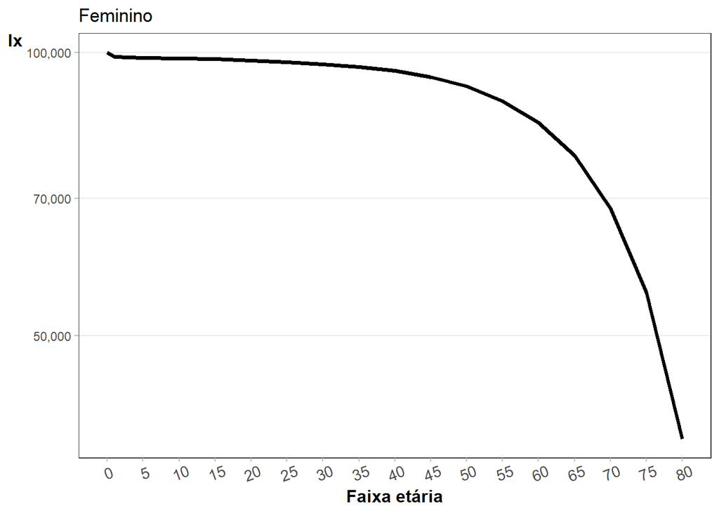

Figure 6: Elaboração própria.

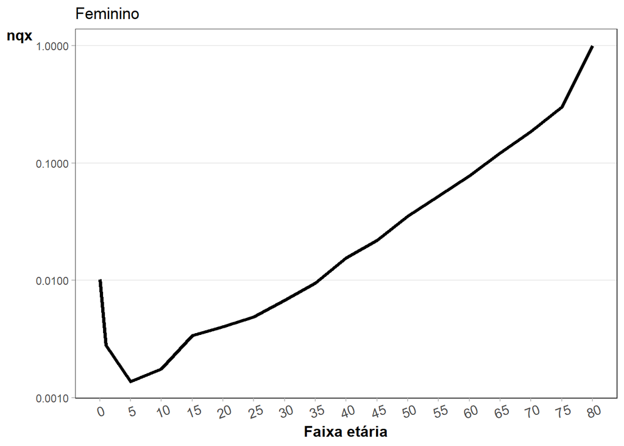

Figure 7: Elaboração própria.

[^1]: Matrícula: 180016946
[^2]: Matrícula: 221036824
[^3]: Matrícula: 160135702
[^4]: Matrícula: 200060023
[^5]: SALDANHA, Raphael de Freitas; BASTOS, Ronaldo Rocha; BARCELLOS, Christovam. Microdatasus: pacote para download e pré-processamento de microdados do Departamento de Informática do SUS (DATASUS). Cad. Saúde Pública, Rio de Janeiro , v. 35, n. 9, e00032419, 2019 . Available from http://ref.scielo.org/dhcq3y.
[^6]: Conforme *GBD 2019 Data and Tools Overview*, disponível em https://ghdx.healthdata.org/gbd-2019.
[^7]: Há um alerta em seu sítio eletrônico de que a rede foi descontinuada.
[^8]: Não há detalhes do efetivamente utilizados na tabela.